title: “GymGraphs” output: html_document date: “2024-09-03”

# Loading the dataset

```r
data <- read.csv("megaGymDataset.csv")
library("ggplot2")
str(data)
```

```
## 'data.frame':    2918 obs. of  9 variables:
##  $ X         : int  0 1 2 3 4 5 6 7 8 9 ...
##  $ Title     : chr  "Partner plank band row" "Banded crunch isometric hold" "FYR Banded Plank Jack" "Banded crunch" ...
##  $ Desc      : chr  "The partner plank band row is an abdominal exercise where two partners perform single-arm planks while pulling "| __truncated__ "The banded crunch isometric hold is an exercise targeting the abdominal muscles, particularly the rectus abdomi"| __truncated__ "The banded plank j…
##  $ Type      : chr  "Strength" "Strength" "Strength" "Strength" ...
##  $ BodyPart  : chr  "Abdominals" "Abdominals" "Abdominals" "Abdominals" ...
##  $ Equipment : chr  "Bands" "Bands" "Bands" "Bands" ...
##  $ Level     : chr  "Intermediate" "Intermediate" "Intermediate" "Intermediate" ...
##  $ Rating    : num  0 NA NA NA NA NA NA NA 8.9 8.9 ...
##  $ RatingDesc: chr  "" "" "" "" ...
```

# Creating histogram of the ‘Rating’ column

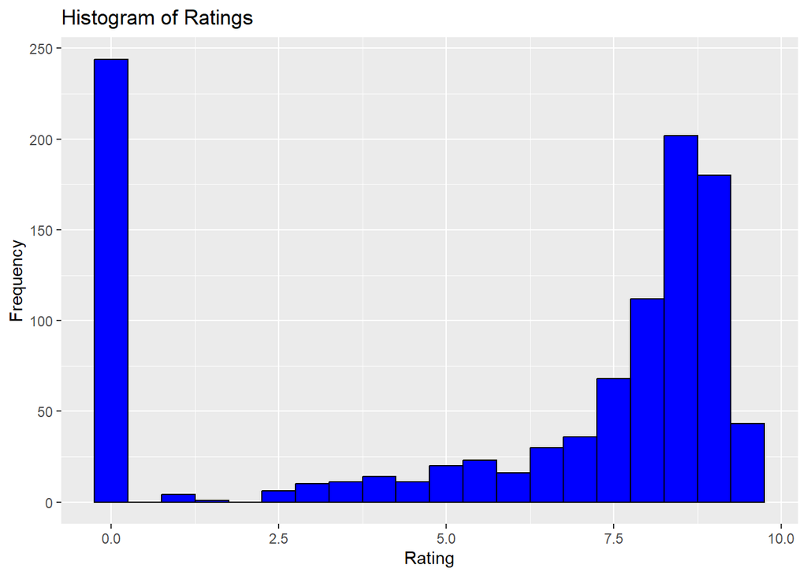

```r
ggplot(data, aes(x = Rating)) +
  geom_histogram(binwidth = 0.5, fill = "blue", color = "black", na.rm = TRUE) +
  labs(title = "Histogram of Ratings", x = "Rating", y = "Frequency")
```

This histogram displays the distribution of Rating values across all exercises in my dataset. The X-Axis represents the rating range, and the Y-Axis shows the frequency, indicating how many exercises fall into each rating bin. It shows whether most exercises have lower or higher ratings.

# Creating bar plot of ‘Type’ vs ‘Rating’

[figure not shown]

```r
ggplot(data, aes(x = Type, y = Rating, fill = Type)) +
  geom_bar(stat = "identity", na.rm = TRUE) +
  labs(title = "Average Rating by Exercise Type", x = "Exercise Type", y = "Average Rating") +
  theme_minimal()
```

# Creating Scatter plot of ‘Difficulty Level vs ’Rating’

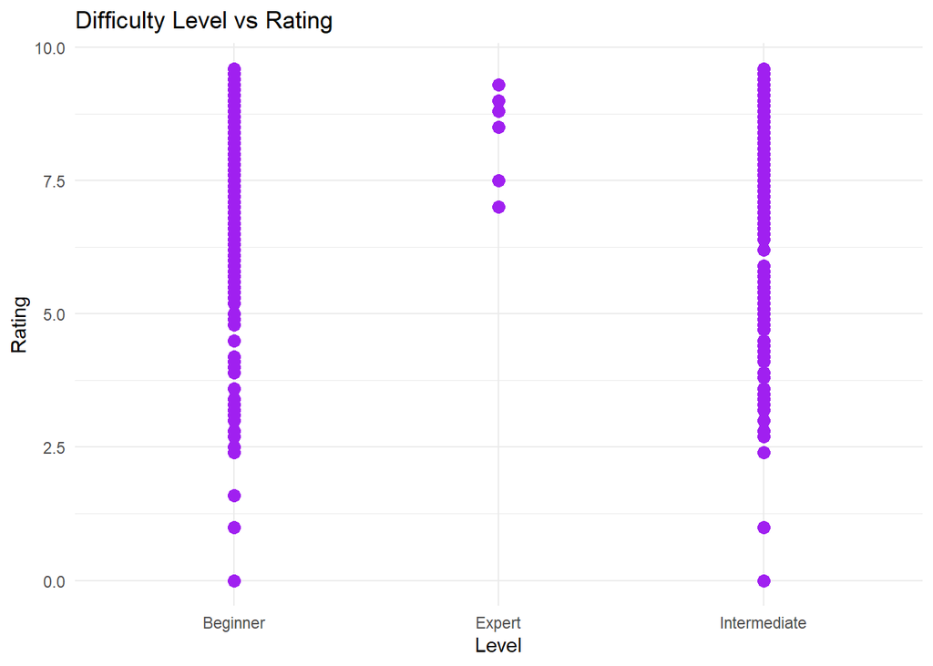

```r
ggplot(data, aes(x = Level, y = Rating)) +
  geom_point(color = "purple", size = 3, na.rm = TRUE) +
  labs(title = "Difficulty Level vs Rating", x = "Level", y = "Rating") +
  theme_minimal()
```

The scatter plot shows the relationship between exercise difficulty and ratings. It helps identify if more difficult exercises tend to receive higher ratings or if difficulty level has little impact on ratings.

# Calculating mean and standard deviation

```r
mean_rating <- mean(data$Rating, na.rm = TRUE)
sd_rating <- sd(data$Rating, na.rm = TRUE)

mean_rating
```

```
## [1] 5.91969
```

```r
sd_rating
```

```
## [1] 3.584607
```

The mean rating provides the average rating of exercises. The standard deviation indicates how much ratings vary from this average, showing the extent of variability in the ratings.

# Calculating correlation

```r
data$Level <- as.numeric(as.factor(data$Level))

correlation <- cor(data$Rating, data$Level, use = "complete.obs")

correlation
```

```
## [1] 0.1947474
```

# T-Test

## Divide the dataset into two groups

```r
group1 <- data[data$Equipment == "Bands", ]
group2 <- data[data$Equipment == "Barbell", ]

t_test_result <- t.test(na.omit(group1$Rating), na.omit(group2$Rating))

t_test_result
```

```
##
##  Welch Two Sample t-test
##
## data:  na.omit(group1$Rating) and na.omit(group2$Rating)
## t = -2.8759, df = 38.846, p-value = 0.006508
## alternative hypothesis: true difference in means is not equal to 0
## 95 percent confidence interval:
##  -3.5837953 -0.6239825
## sample estimates:
## mean of x mean of y
##  4.333333  6.437222
```

The t-test compares ratings between exercises using Bands and those using Barbells. The result shows a significant difference: exercises with Barbells receive higher ratings compared to those with Bands. This difference is statistically significant, meaning it is unlikely to be due to random chance. `